# Análisis de datos en Vigilancia Epidemiológica II: análisis de datos espaciales

Andree Valle Campos avallecam@gmail.com

2021-06-29

# Advertencias

> Este documento es una continuación de [**Análisis de datos en Vigilancia Epidemiológica I: tiempo, espacio, persona y curva epidémica**](https://rpubs.com/avallecam/episurv2021parte1). Retorna a dicho documento para recordar las advertencias.

> Este documento está vinculado a las siguientes [diapositivas](https://bit.ly/episurv2021parte2)

> Material original de [“Small Area Disease Risk Estimation and Visualization Using R” Paula Moraga, The R Journal (2018) 10:1, pages 495-506](https://journal.r-project.org/archive/2018/RJ-2018-036/index.html) actualizado por la misma autora [aquí](https://www.paulamoraga.com/tutorial-areal-data-es/). Adaptación disponible [aquí](https://github.com/avallecam/spclustr/blob/master/moraga-RJ-2018-036.R)

# Contexto

En este tutorial usamos metodos espaciales para estimar el riesgo de cancer de pulmon en Pensilvania, Estados Unidos, en el año 2002.

Usamos datos del paquete de R `SpatialEpi` con la poblacion, los casos de cancer de pulmón, y las proporciones de fumadores en cada uno de los condados de Pensilvania.

Los datos de **poblacion** se han obtenido del censo del año 2000, y los **casos** de cancer y la **proporción** de fumadores de la pagina web del Departamento de Salud de Pensilvania.

# Objetivos

- Calcular por cada Condado/Distrito dentro de un Estado/Departamento el: (i )número de casos observados y esperados usando el paquete `SpatialEpi`, y (ii) las razones de mortalidad estandardizadas (*Standardized Mortality Ratios* o *SMR*).
- Obtener estimaciones del riesgo relativo de la enfermedad y cuantificar factores de riesgo usando el paquete `INLA`.
- Crear un mapa con las estimaciones de riesgo usando `ggplot2`.

# 07 - análisis espacial

## instalar paquetes

- Aquí la lista de los paquetes requeridos:

```r
if(!require("tidyverse")) install.packages("tidyverse")
if(!require("sf")) install.packages("sf")
if(!require("SpatialEpi")) install.packages("SpatialEpi")
if(!require("spdep")) install.packages("spdep")
if(!require("leaflet")) install.packages("leaflet")
```

- El paquete `INLA` no está en CRAN porque utiliza algunas librarías externas que dificultan la construcción de los binarios.
- Por lo tanto, necesitamos instalarlo añadiendo la URL del repositorio INLA:

```r
if(!require("INLA")) install.packages("INLA", repos = "https://inla.r-inla-download.org/R/stable", dep = TRUE)
```

## librerias a usar

```r
library(tidyverse)
library(sf)
```

## importar base de datos

- Extraer los datos `pennLC` que vienen en el paquete `SpatialEpi`

```r
library(SpatialEpi)

# llamar a base de datos dentro de paquete
data(pennLC)
```

> **P: ¿Qué tipo de objeto es `pennLc`? ¿Qué elementos contiene?**

```r
# ¿qué tipo de objeto es?


# identificar sus atributos
attributes(pennLC)
```

## _preparar base de datos

### casos observados

- Usa `group_by() %>% summarise()` para crear una base de datos **resumen** con la suma `sum` de casos (`Y`) y suma total de población (`pop`) por condado/distrito

```r
pennLC$data %>%
  as_tibble() %>%
  group_by(county) %>%
  summarise(Y=sum(cases),
            pop=sum(population)) %>%
  ungroup()
```

### variables exposición

- Unir con `left_join()` la proporción de fumadores `smoking` por condado/distrito

```r
pennLC$smoking
```

### agregar polígonos

- Unir con `left_join()` los polígonos de cada condado/distrito
- Utilizar el número de orden de cada condado/distrito para unir la información

> (en el mejor de los casos, deberían disponer de los **ubigeos**)

```r
pennLC$spatial.polygon %>%
              st_as_sf() %>%
              as_tibble() %>%
              rownames_to_column()
```

- Asignar el resultado final al objeto `d`

```r
#outcome at county level + covariates (race,sex,age_strata)
d <- pennLC$data %>%
  as_tibble() %>%
  group_by(county) %>%
  summarise(Y=sum(cases),
            pop=sum(population)) %>%
  ungroup() %>%

  #add exposure at county level
  left_join(pennLC$smoking) %>%
  rownames_to_column() %>%

  #add polygon to tibble
  left_join(pennLC$spatial.polygon %>%
              st_as_sf() %>%
              as_tibble() %>%
              rownames_to_column())
```

- Visualizar casos observados

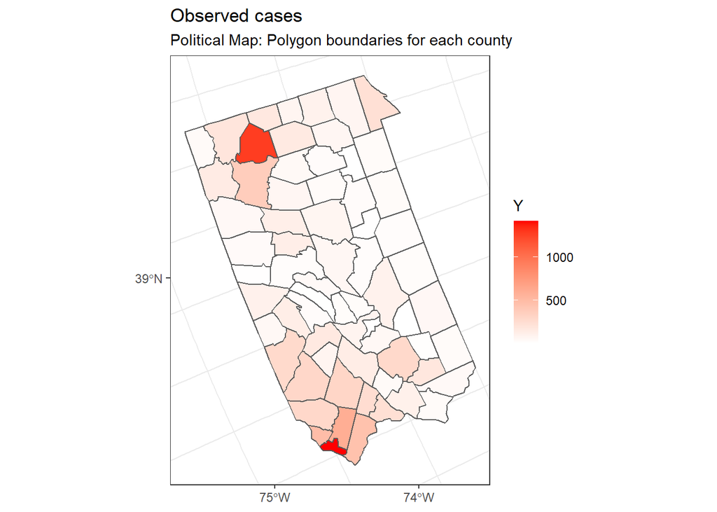

```r
d %>%
  st_as_sf() %>%
  st_transform(crs = 27700) %>%
  ggplot(aes(fill=Y)) +
  geom_sf() +
  scale_fill_gradient(low = "white",high = "red") +
  guides(fill = guide_colorbar(reverse=F)) +
  theme_bw() +
  labs(title = "Observed cases",
       subtitle = "Political Map: Polygon boundaries for each county")
```

## _calcular casos esperados

- Ojo: El cálculo tomará en cuenta todos los **estratos**
- Asigna la base de datos al objeto `e`

```r
# Expected cases (using stratas!) ---------------------------------
e <- pennLC$data %>%
  as_tibble() %>%
  select(county,cases,population,race,gender,age)
```

- Usar `count()` para identificar la cantidad de combinación de **estratos** por variable categórica

```r
e %>% count(county) #67

e %>% count(race,gender,age) #16
```

- Calcular los casos esperados usando la función `expected()`

```r
population <- e$population
cases <- e$cases
n.strata <- 16 # = 2 races * 2 genders * 4 age bands
E <- expected(population, cases, n.strata)
```

> **P: Explorar `E`, ¿qué longitud tiene? ¿a qué nivel de agregación corresponden estos resultados?**

```r
E
```

## _calcular SMR

- Agregar con `mutate()` el número de casos esperados (`E`) a una lísta de condados/distritos

```r
e %>%
  select(county) %>%
  distinct() %>%
  mutate(E=E)
```

- Unir con `left_join()` la base resumen `d` con la cantidad de casos esperados `E`

```r
d %>%
  left_join(
    e %>%
      select(county) %>%
      distinct() %>%
      mutate(E=E)
  )
```

- Usar `mutate()` para crear la variable `SMR`

```r
d %>%
  left_join(
    e %>%
      select(county) %>%
      distinct() %>%
      mutate(E=E)
  ) %>%
  mutate(SMR=Y/E)
```

- Usar la función `st_as_sf()` para crear un objeto tipo `sf`
- Usar la función `as('Spatial')` para transformar objeto `sf` a `SpatialPolygonDataFrame`
- Asignar resultado final al objeto `map`

```r
map <- d %>%
  left_join(
    e %>%
      select(county) %>%
      distinct() %>%
      mutate(E=E)
  ) %>%
  mutate(SMR=Y/E) %>%
  # add data to map
  st_as_sf() %>%
  # transform to SpatialPolygonDataFrame
  as('Spatial')
```

> **P: ¿Qué información clave caracteriza a un objeto espacial?**

### crear un gráfico con `ggplot2`

- Usar la plantilla de `ggplot2` para crear un mapa

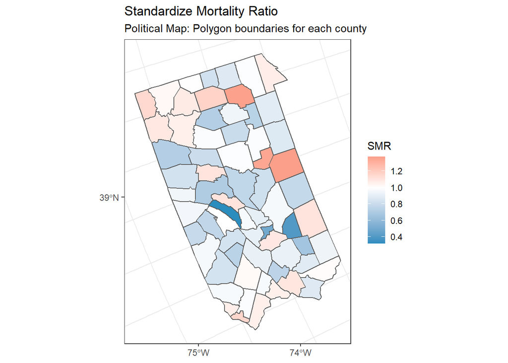

```r
# Mapping SMR ---------------------------------
map %>%
  st_as_sf() %>%
  st_transform(crs = 27700) %>%
  ggplot(aes(fill=SMR)) +
  geom_sf() +
  scale_fill_gradient2(high = "#e34a33",low = "#2b8cbe",midpoint = 1) +
  guides(fill = guide_colorbar(reverse=F)) +
  theme_bw() +
  labs(title = "Standardize Mortality Ratio",
       subtitle = "Political Map: Polygon boundaries for each county")
```

- Crear un [cartograma](https://www.r-graph-gallery.com/cartogram.html)

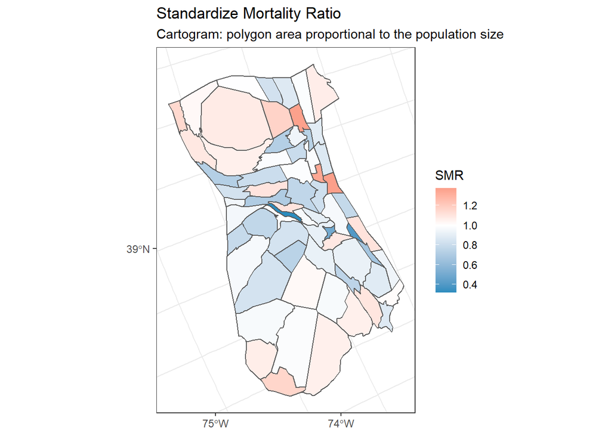

```r
# alternative - cartogram
map_carto <- map %>%
  st_as_sf() %>%
  st_transform(crs = 27700) %>%
  cartogram::cartogram_cont("pop", itermax=5)

map_carto %>%
  st_as_sf() %>%
  ggplot(aes(fill=SMR)) +
  geom_sf() +
  scale_fill_gradient2(high = "#e34a33",low = "#2b8cbe",midpoint = 1) +
  guides(fill = guide_colorbar(reverse=F)) +
  theme_bw() +
  labs(title = "Standardize Mortality Ratio",
       subtitle = "Cartogram: polygon area proportional to the population size")
```

> **P: ¿Qué problema observa con esta visualización?**

## _modelo de regresión espacial

### extraer matriz de vecindad

- Usar función `poly2nb()` de paquete `spdep` para extraer polígonos vecinos
- `nb2INLA()` de paquete `INLA` para generar archivo local a ser usado por `inla()`

```r
# Neighbourhood matrix ---------------------------------
library(spdep)
library(INLA)
nb <- poly2nb(map)
head(nb)
```

```
## [[1]]
## [1] 21 28 67
##
## [[2]]
## [1]  3  4 10 63 65
##
## [[3]]
## [1]  2 10 16 32 33 65
##
## [[4]]
## [1]  2 10 37 63
##
## [[5]]
## [1]  7 11 29 31 56
##
## [[6]]
## [1] 15 36 38 39 46 54
```

```r
nb2INLA("map.adj", nb)
g <- inla.read.graph(filename = "map.adj")
```

### realizar inferencia

- indexar efectos aleatorios
- crear fórmula
- ejecutar la función `inla`

```r
# Inference using INLA ---------------------------------

#index both random effects
map$re_u <- 1:nrow(map@data) #spatial residual variation
map$re_v <- 1:nrow(map@data) #modeling unstructure noise

#create formula
#iid: independent and identically distributed
formula <-
  Y ~ # outcome
  smoking + # exposure
  f(re_u, model = "besag", graph = g) + #random effect - spatial
  f(re_v, model = "iid") #random effect - noise

res <- inla(formula,
            family = "poisson",
            data = map@data,
            E = E,
            control.predictor = list(compute = TRUE))
```

### visualizar resultados

- Inspeccionar la salida resumen en crudo del modelo

```r
summary(res)
```

```
##
## Call:
##    c("inla(formula = formula, family = \"poisson\", data = map@data, ", "
##    E = E, control.predictor = list(compute = TRUE))")
## Time used:
##     Pre = 1.98, Running = 2.64, Post = 1.16, Total = 5.78
## Fixed effects:
##               mean    sd 0.025quant 0.5quant 0.975quant   mode kld
## (Intercept) -0.323 0.150     -0.621   -0.323     -0.028 -0.323   0
## smoking      1.156 0.624     -0.080    1.157      2.384  1.160   0
##
## Random effects:
##   Name     Model
##     re_u Besags ICAR model
##    re_v IID model
##
## Model hyperparameters:
##                        mean       sd 0.025quant 0.5quant 0.975quant    mode
## Precision for re_u    92.67    50.19      31.00    81.16     221.44   62.96
## Precision for re_v 18097.70 18216.37    1165.24 12665.38   66267.31 3144.29
##
## Expected number of effective parameters(stdev): 18.66(4.43)
## Number of equivalent replicates : 3.59
##
## Marginal log-Likelihood:  -320.54
## Posterior marginals for the linear predictor and
##  the fitted values are computed
```

- Extraer la distribución posterior del coeficiente $\beta_1$
- Visualizar con `ggplot2`

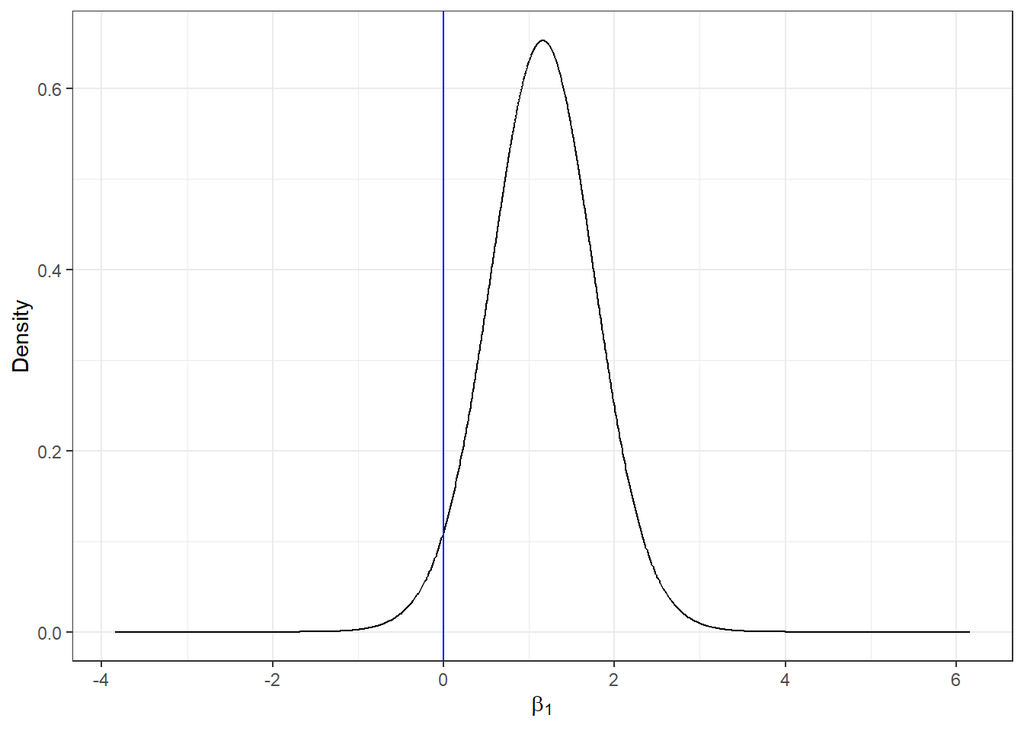

```r
marginal <- inla.smarginal(res$marginals.fixed$smoking) %>%
  data.frame()

ggplot(marginal, aes(x = x, y = y)) +
  geom_line() +
  geom_vline(xintercept = 0, col = "blue") +
  labs(x = expression(beta[1]),
       y = "Density") +
  theme_bw()
```

- Extraer **predictores lineales** del desenlace del modelo
- Visualizar con `ggplot2`

```r
head(res$summary.fitted.values)
```

```
##                          mean         sd 0.025quant  0.5quant 0.975quant
## fitted.Predictor.01 0.8796107 0.05846419  0.7639557 0.8798268  0.9947103
## fitted.Predictor.02 1.0598951 0.02765373  1.0069360 1.0594517  1.1153543
## fitted.Predictor.03 0.9627956 0.05193450  0.8552488 0.9644781  1.0611516
## fitted.Predictor.04 1.0268012 0.05129911  0.9266835 1.0264757  1.1289543
## fitted.Predictor.05 0.9078911 0.05495643  0.7984740 0.9082307  1.0161501
## fitted.Predictor.06 0.9953488 0.04033642  0.9184137 0.9944626  1.0774326
##                          mode
## fitted.Predictor.01 0.8807642
## fitted.Predictor.02 1.0585487
## fitted.Predictor.03 0.9679679
## fitted.Predictor.04 1.0260002
## fitted.Predictor.05 0.9094453
## fitted.Predictor.06 0.9928306
```

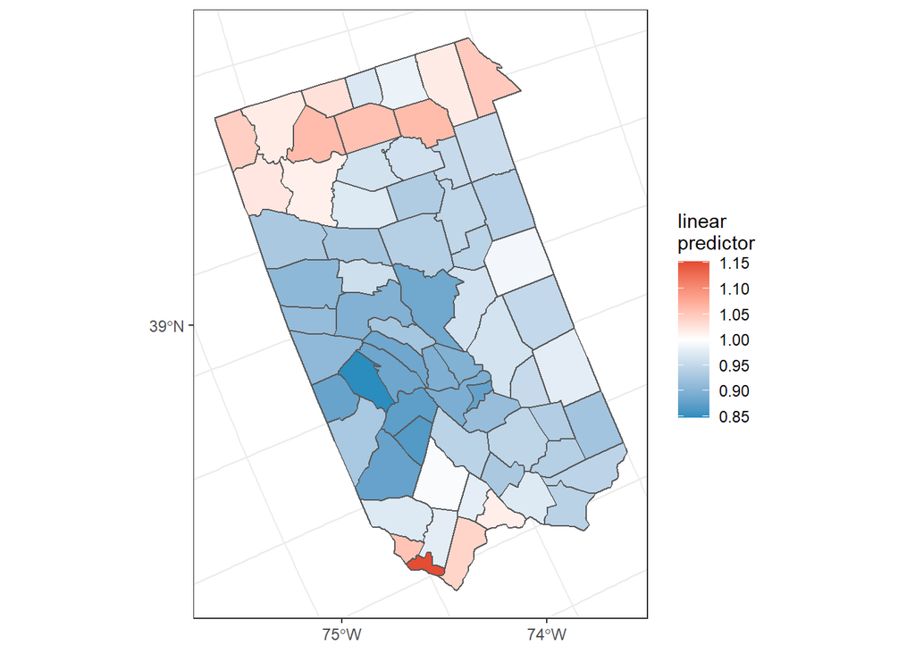

```r
map$RR <- res$summary.fitted.values[, "mean"]
map$LL <- res$summary.fitted.values[, "0.025quant"]
map$UL <- res$summary.fitted.values[, "0.975quant"]

map %>%
  st_as_sf() %>%
  st_transform(crs = 27700) %>%
  ggplot(aes(fill=RR)) +
  geom_sf() +
  scale_fill_gradient2(high = "#e34a33",low = "#2b8cbe",midpoint = 1) +
  guides(fill = guide_colorbar(reverse=F)) +
  labs(fill = "linear\npredictor") +
  theme_bw()
```

- Crear un [cartograma](https://www.r-graph-gallery.com/cartogram.html)

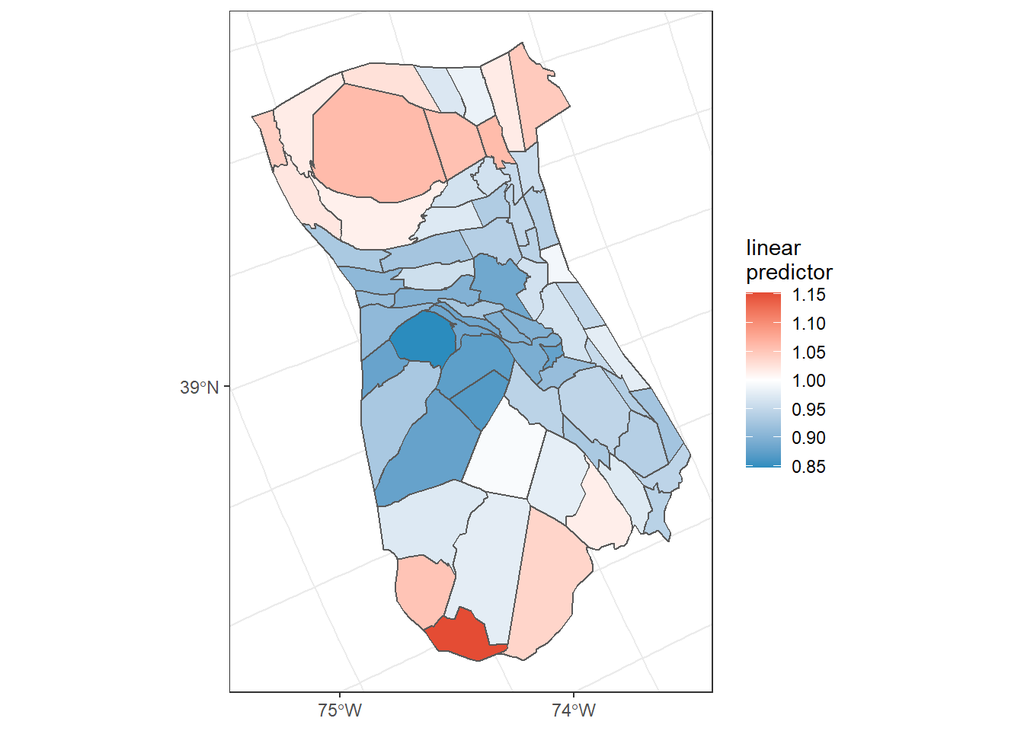

```r
map_carto <- map %>%
  st_as_sf() %>%
  st_transform(crs = 27700) %>%
  cartogram::cartogram_cont("pop", itermax=5)

map_carto %>%
  st_as_sf() %>%
  ggplot(aes(fill=RR)) +
  geom_sf() +
  scale_fill_gradient2(high = "#e34a33",low = "#2b8cbe",midpoint = 1) +
  guides(fill = guide_colorbar(reverse=F)) +
  labs(fill = "linear\npredictor") +
  theme_bw()
```

# RETROALIMENTACIÓN

- retornar a [diapositiva](https://docs.google.com/presentation/d/1EupjEr0OMlQO6y3C_itItHa-RrE_E4RH4aYP_Kj4Psk/edit#slide=id.ge2878c9bb6_0_75)

# 08 - cierre

## ¡Gracias por su atención!

### Andree Valle Campos **`@avallecam`** [click aquí](https://twitter.com/avallecam) **avallecam@gmail.com**